# Préparation CCF E5.2 : Station météo

Ce système sera utilisé dans le cadre de l’épreuve de CCF E5.2.

## Présentation

Dans le cadre d’une application d’informations météorologiques locales, ce système est capable d’afficher sur un panneau lumineux extérieur des bulletins comprenant les mesures de vitesse du vent et sa direction, de température de l’air, de pression atmosphérique et d’humidité relative.

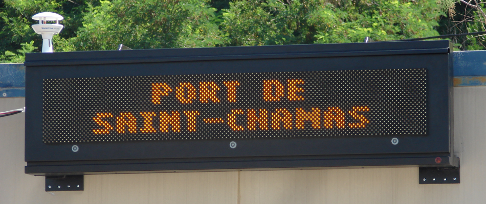

Le système est architecturé autour :

- d’une station météo Maretron WSO-100 qui mesure la vitesse du vent, sa direction, la température de l’air, la pression atmosphérique et l’humidité relative. La mesure du vent est effectuée à l’aide de capteurs ultrason. L’absence de pièce en mouvement dans la station assure une longue durée de vie, une bonne fiabilité et un coût d’entretien nul.
- d’un panneau d’affichage extérieur Led Moving Sign qui possède deux lignes de 16 caractères permettant d’afficher périodiquement les informations météorologiques. Le panneau lumineux communique via une liaison « Ethernet TCP/IP ».

[figure not shown]

La station Maretron WSO-100 émet périodiquement sur un bus CAN deux messages NMEA2000 (qui contiennent les mesures de la vitesse du vent, sa direction, la température de l’air, la pression atmosphérique et l’humidité relative). Après traitement et vérification de leur validité, les mesures sont affichables dans un bulletin météo et exportées au format CSV pour une exploitation extérieure (logiciel de type tableur).

La communication entre le PC et la station météo Maretron WSO-100 nécessite une liaison « NMEA2000 » assurée par l’interface de communication CAN/USB.

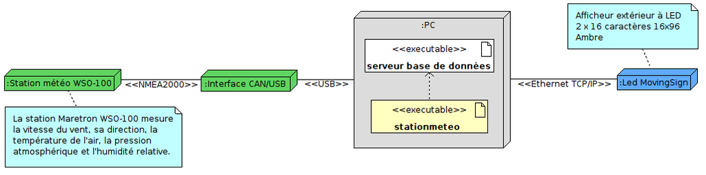

Le diagramme des cas d’utilisation du système est le suivant :

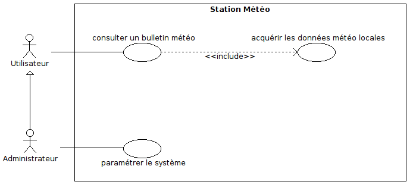

L’utilisateur consulte le bulletin météo diffusé périodiquement sur le panneau lumineux.

L’administrateur configure le système en paramétrant les périodes d’acquisition des mesures et de rafraîchissement des données sur le panneau lumineux. Il a aussi la possibilité de choisir les données à intégrer au bulletin météo et de personnaliser des messages qui seront diffusés sur le le panneau lumineux.

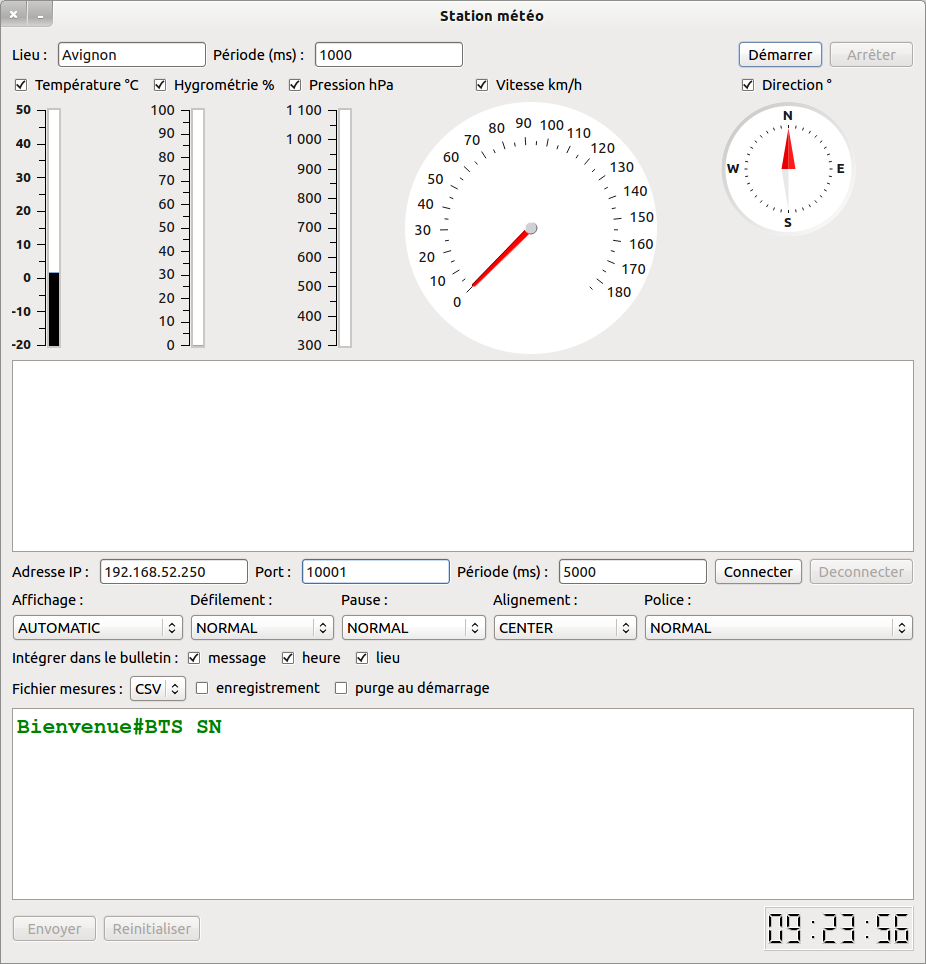

## Contraintes d’environnement

| Ressource | Version |
| --- | --- |
| OS | GNU Linux (Ubuntu 12.04.5 LTS) |
| EDI | Qt Creator 2.4.1 |
| Compilateur | GNU g++/gcc version 4.6.3 |
| Débugueur | GNU gdb 7.4 |
| Fabrication | QMake 2.01a et GNU make 3.81 |
| API GUI | Qt 4.8.1 |

## Manuel d’installation

Exécuter le programme d’installation setup ou la version simulateur setup et suivre les différentes étapes :

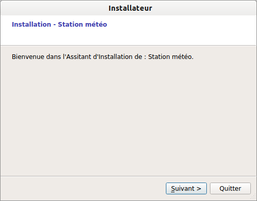

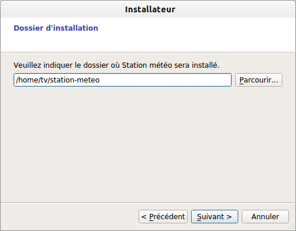

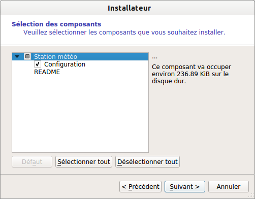

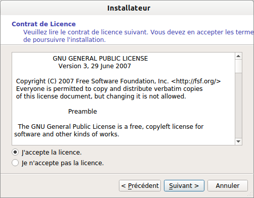

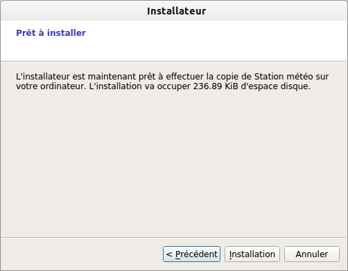

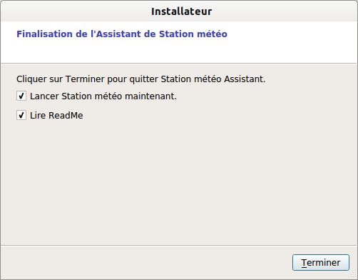

L’application gère ses paramètres de configuration à partir d’un fichier `station-meteo.ini` :

```
[wso-100]
# Le lieu de l'installation
lieu=Avignon
# Le PGN du message NMEA2000 qui contient les données de vent
pgn-wind-data=130306
# Le PGN du message NMEA2000 qui contient les données de température, hygrométrie et pression atmosphérique
pgn-environmental-parameters=130311
# La période d'acquisition des mesures en ms
periode=1000
# Mettre à on pour valider l'enregistrement en continu des mesures
enregistrement=off
# Le format de fichier d'exportation des mesures (seul le format CSV est supporté dans cette version)
format=csv
# Mettre à on pour vider le fichier de mesures en début d'enregistrement
purge=off
# Mettre à on ou auto pour démarrer l'acquisition au lancement de l'application
demarrage=off

[panneau]
# L'adresse IP du panneau
adresse=192.168.52.250
# Le numéro de port TCP du panneau
port=10001
# La période de rafraichissement du bulletin sur le panneau en ms
periode=60000
# Un message personnalisé (le # correspond à un saut de ligne sur l'afficheur)
message=Bienvenue#BTS SN
# le type d'affichage (0 pour AUTOMATIC, 2 pour FIX, ...)
affichage=0
# la vitesse de défilement (0 pour FASTER, 1 pour FAST, 2 pour NORMAL, 4 pour SLOW et 5 pour SLOWER)
vitesse=2
# le temps de pause (5 pour NORMAL)
pause=5
# l'alignement du texte (0 pour gauche, 1 pour droite et 2 pour centré)
alignement=2
# la taille de la police (0 pour SMALL, ... 5 pour NORMAL, ...)
taille=5
# Mettre à on ou auto pour démarrer l'affichage des bulletins au lancement de l'application
connexion=off

# Les données à intégrer (true) ou pas (false) dans le bulletin
[bulletin]
temperature=true
hygrometrie=true
pression=true
vitesse=true
direction=true
message=true
heure=true
lieu=true
```

La configuration du bus CAN est stockée dans le fichier `bus-can.ini` :

```
[buscan]
# Le fichier de périphérique (dans /dev) de l'interface PCAN-USB
interface=pcan0
# Le débit en bits/s
debit=250000
# Le type de trame (std pour standard et ext pour étendu)
type=ext
# L'adresse de la station météo si il y en a plusieurs sinon mettre 0
adresse=0
```

*Remarque :* Sous Ubuntu > 12.04, il faudra aussi installer le paquet libqwt6_6.0.0-1.2_amd64.deb :

```
$ sudo dpkg -i libqwt6_6.0.0-1.2_amd64.deb
```

## Manuel d’utilisation

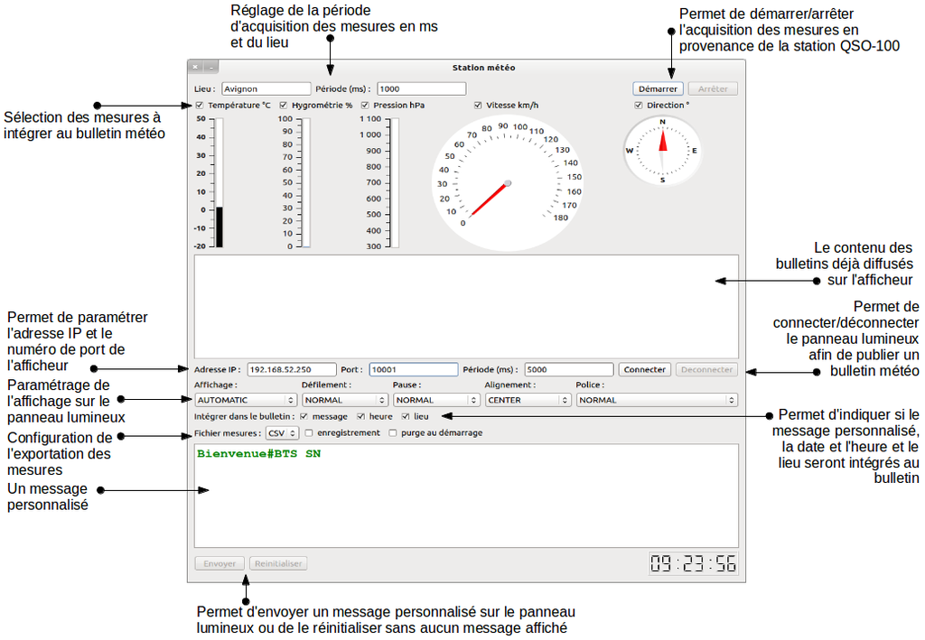

```
L'application consigne des messages, évènements, avertissements et erreurs dans un journal station-meteo.log.
```

## Glossaire

- Température : La température est une grandeur physique mesurée à l’aide d’un thermomètre et étudiée en thermométrie. La température est une variable importante dans d’autres disciplines : météorologie et climatologie, médecine, et chimie. L’échelle de température la plus répandue est le degré Celsius, dans laquelle la glace (formée d’eau) fond à 0 °C et l’eau bout à environ 100 °C dans les conditions standard de pression. Dans les pays utilisant le système impérial (anglo-saxon) d’unités, on emploie le degré Fahrenheit où la glace fond à 32 °F et l’eau bout à 212 °F. L’unité du système international d’unités (SI), d’utilisation scientifique et définie à partir du zéro absolu, est le kelvin1 dont la graduation est presque identique à celle des degrés centigrades.
- Hygrométrie : L’hygrométrie caractérise l’humidité de l’air, à savoir la quantité d’eau sous forme gazeuse présente dans l’air humide (ou dans un autre gaz, dans certaines applications industrielles). On définit trois types d’hygrométrie (absolue, relatibve et spécifique, chacun a sa mesure associée). L’ygrométrie relative est l’humidité absolue en proportion de la valeur maximum, pour une température donnée, exprimée en pourcentage. En météorologie, l’humidité relative ( souvent appelée degré hygrométrique) fait partie des principales quantités relevées et modélisées. Elle se mesure avec un hygromètre ou avec un thermohygromètre (car température et humidité de l’air sont deux paramètres pour partie interdépendants).
- Pression atmosphérique : La pression atmosphérique est la pression qu’exerce le mélange gazeux constituant l’atmosphère considérée (sur Terre : de l’air) sur une surface quelconque au contact avec cette atmosphère. Sur Terre, la pression atmosphérique moyenne au niveau de la mer dépend essentiellement de la masse de l’atmosphère, celle-ci pouvant évoluer avec la masse moyenne des gaz à concentration variable comme la vapeur d’eau. Elle varie autour de l’atmosphère normale, soit 1 013,25 hPa. La pression atmosphérique se mesure surtout à l’aide d’un baromètre, d’un hypsomètre ou d’un altimètre. Depuis l’adoption du pascal comme unité de pression, les météorologues utilisent un multiple de cette unité, l’hectopascal (1 hPa = 100 Pa).
- Anémomètre : Un anémomètre est un terme du xviiie siècle, composé du préfixe « anémo » (en français « vent ») et du suffixe « mètre » (« mesure »). Il s’agit donc d’un appareil permettant de mesurer la vitesse ou la pression du vent. L’anémomètre est un instrument essentiel en météorologie car le vent est un des paramètres qui déterminent l’évolution du temps et de la prévision météorologique. Il existe des anémomètres à ultrasons qui ont été développé à partir des années 1950. La mesure du vent est basée sur la mesure de la durée de déplacement d’une onde ultrasonore. Deux couples de transducteurs ultrasonore sont alternativement émetteurs et récepteurs d’un train d’onde ultrasonore. Les temps de transit aller et retour sont mesurés et on en déduit, par différence de fréquence (suivant le principe de l’effet Doppler), la vitesse du vent le long de l’axe formé par les deux transducteurs. L’intérêt de ce type d’anémomètre est de ne pas avoir de pièces en mouvement et de pouvoir mesurer un vent turbulent. Le nœud est une unité de mesure de la vitesse utilisée en navigation maritime et aérienne. Un nœud correspond à un mille marin par heure, soit 1,852 km par heure ou 0,514 mètre par seconde. Le nœud n’appartient pas au système international (SI). On utilise généralement pour cette unité les symboles nd ou kt (pour nœud, *knot* en anglais).
- Une girouette est un dispositif dont la fonction est de montrer la provenance du vent (une croix directionnelle indiquant les quatre points cardinaux). Toutefois, les girouettes modernes sont équipées d’un dispositif électronique affichant le secteur du vent sur un écran. Les instituts de surveillance météorologique utilisent des girouettes automatiques pour la mesure de la direction du vents. Plusieurs technologies sont utilisées pour la mesure de direction de vents, la plus utilisée est celle avec un potentiomètre électronique. Depuis, quelques années les capteurs de vent à ultrasons peuvent également substituer les girouettes automatiques traditionnelles.

## Activités

- Matériels : Afficheur lumineux LED Moving Sign, Station météo WSO-100 de Maretron
- Interfaces de communication : PCAN-USB, Ethernet
- Bus de terrain : CAN/NMEA2000
- Réseau : TCP/IP
- Fichiers : LOG, INI et CSV
- Autre(s) : PHP

Retour au sommaire